# HW2-Fangzhou Song

Fangzhou Song

## Coding Algorithm

1. The initialization step. Note that the parameters for each cluster, $\lambda_1$ and $\lambda_2$ have to be positive.

```r
em_init=function(x){
  lam1=quantile(x,0.7)
  lam2=quantile(x,0.3)
  return(c(lam1,lam2))
}
```

2. The E-step. If you know what you are doing, this step should be straightforward. You just need to use the dpois function.

```r
em_e=function(x,lam1,lam2){
  p1=dpois(x,lambda = lam1)
  p2=dpois(x,lambda = lam2)
  return(p1/(p1+p2))
}
```

3. The M-step. Use your result from the question 2.

$$\lambda_k=\frac{\sum_{i=1}^{n} {\pi_{i,k}x_i}}{\sum_{i=1}^{n} {\pi_{i,k}}}$$

```r
em_m=function(x,z){
  lam1=sum(x*z)/sum(z)
  lam2=sum(x*(1-z))/sum(1-z)
  return(c(lam1,lam2))
}
```

4. Put it together

```r
em_poisson=function(x,iter.max=100,conv.check=1e-4){
  init_para=em_init(x)
  lam1=init_para[1]
  lam2=init_para[2]

  previous_para=init_para

  for(t in 1:iter.max){
    e_result=em_e(x,lam1,lam2)   #E-step
    m_result=em_m(x,e_result)    #m-Step
    lam1=m_result[1]
    lam2=m_result[2]

    #stop the algorithm if we achieved convergence
    if(max(abs(m_result-previous_para)) < conv.check) break;

    previous_para=m_result
  }

  return(list(z=e_result,
              lam=m_result))
}
```

## Check it using simulation

5. Generate random Poisson samples with the following R code, and test how well your algorithm works in finding the clusters and the cluster parameters:

```r
set.seed(233)
lambda1 <- 10
lambda2 <- 1.2

n1 <- 50
n2 <- 50

x1 <- rpois(n1,lambda1)
x2 <- rpois(n2,lambda2)

x <- c(x1,x2)
```

```r
fit1=em_poisson(x)
fit1
```

```
## $z
##   [1] 0.999999846 0.999999846 0.999943888 0.979903805 0.999998902
##   [6] 0.999999997 1.000000000 0.979903805 0.999598958 0.999943888
##  [11] 0.999999846 0.999998902 0.999999846 0.997139756 0.997139756
##  [16] 0.999943888 0.999992151 0.999943888 0.997139756 0.999998902
##  [21] 0.999943888 0.999998902 0.997139756 1.000000000 0.999598958
##  [26] 0.999943888 0.872123239 0.999999846 0.999998902 0.999992151
##  [31] 0.999992151 0.999598958 0.488203081 0.999998902 0.979903805
##  [36] 0.999999997 0.999943888 0.999943888 0.999998902 0.979903805
##  [41] 0.999992151 0.999598958 0.999598958 0.999598958 0.999998902
##  [46] 0.999943888 0.488203081 0.999998902 0.979903805 0.872123239
##  [51] 0.002603279 0.000364931 0.018319195 0.018319195 0.000364931
##  [56] 0.000364931 0.018319195 0.018319195 0.002603279 0.018319195
##  [61] 0.018319195 0.018319195 0.000364931 0.002603279 0.018319195
##  [66] 0.117714176 0.018319195 0.488203081 0.000364931 0.002603279
##  [71] 0.018319195 0.018319195 0.117714176 0.002603279 0.002603279
##  [76] 0.000364931 0.002603279 0.000364931 0.000364931 0.488203081
##  [81] 0.002603279 0.000364931 0.002603279 0.002603279 0.002603279
##  [86] 0.002603279 0.002603279 0.002603279 0.488203081 0.000364931
##  [91] 0.000364931 0.000364931 0.117714176 0.117714176 0.000364931
##  [96] 0.018319195 0.018319195 0.000364931 0.000364931 0.002603279
##
## $lam
## [1] 9.202479 1.287089
```

It shows that $\hat\lambda_1$=9.202479, $\hat\lambda_2$=1.287089, which are approximate to 10 and 1.2

Result check

```r
fit1$z > 0.5
```

```
##   [1]  TRUE  TRUE  TRUE  TRUE  TRUE  TRUE  TRUE  TRUE  TRUE  TRUE  TRUE
##  [12]  TRUE  TRUE  TRUE  TRUE  TRUE  TRUE  TRUE  TRUE  TRUE  TRUE  TRUE
##  [23]  TRUE  TRUE  TRUE  TRUE  TRUE  TRUE  TRUE  TRUE  TRUE  TRUE FALSE
##  [34]  TRUE  TRUE  TRUE  TRUE  TRUE  TRUE  TRUE  TRUE  TRUE  TRUE  TRUE
##  [45]  TRUE  TRUE FALSE  TRUE  TRUE  TRUE FALSE FALSE FALSE FALSE FALSE
##  [56] FALSE FALSE FALSE FALSE FALSE FALSE FALSE FALSE FALSE FALSE FALSE
##  [67] FALSE FALSE FALSE FALSE FALSE FALSE FALSE FALSE FALSE FALSE FALSE
##  [78] FALSE FALSE FALSE FALSE FALSE FALSE FALSE FALSE FALSE FALSE FALSE
##  [89] FALSE FALSE FALSE FALSE FALSE FALSE FALSE FALSE FALSE FALSE FALSE
## [100] FALSE
```

Use 0.5 as cut-off. If z > 0.5, we can regrad it as the member of cluster 1, cluster 2 otherwise. It shows that most of predictions are correct.

## Real life Application

6. Download the DJI_vol.csv dataset from Blackboard. In this dataset, you will find the total number of volatile days that the Dow Jones Index had for each month. Here, the number of volatile days is defined as the number of days in which the absolute value of the daily return is higher than 1%.

Read data

```r
library(tidyverse)
library(lubridate)
data=read_csv("DJI_vol.csv")
```

Time-series plot

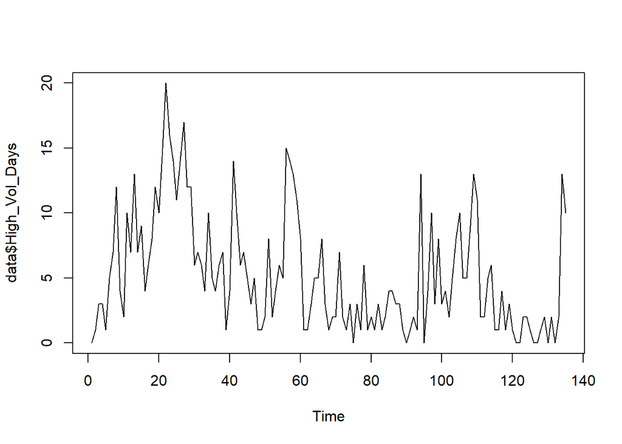

```r
ts.plot(data$High_Vol_Days)
```

Cluster estimates

```r
result=em_poisson(data$High_Vol_Days)
result$lam
```

```
## [1] 9.356897 2.126580
```

Plot the cluster assignments in time

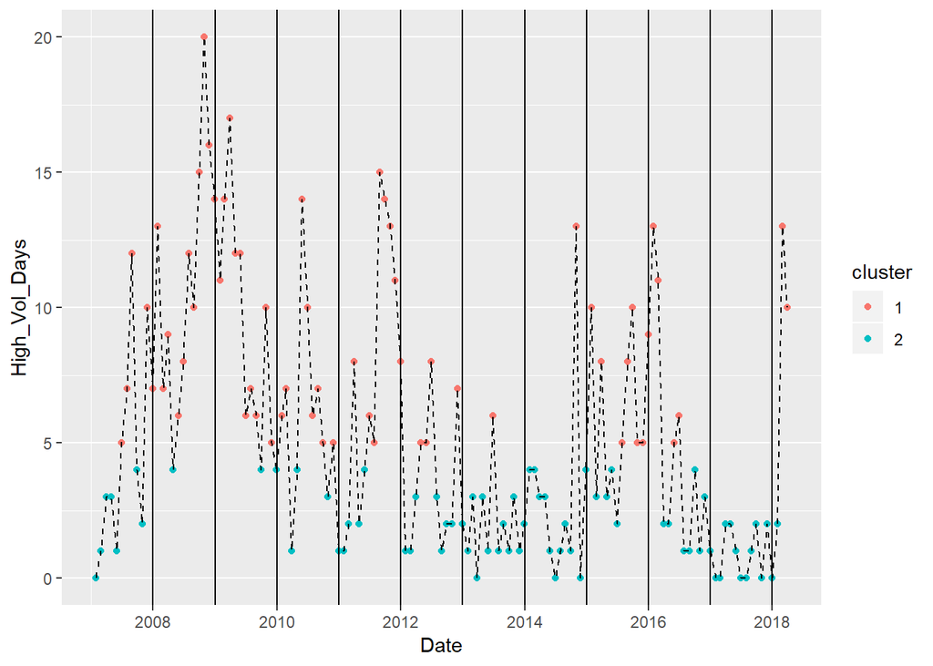

```r
data_2=cbind(data,result$z)
data_3=data_2 %>%
  mutate(
    cluster=as.factor(if_else(result$z > 0.5,1,2)),
    Date=ymd(Date)
  )
ggplot(data = data_3)+
  geom_point(mapping = aes(x=Date,y=High_Vol_Days,color=cluster))+
  geom_line(mapping = aes(x=Date,y=High_Vol_Days),linetype=2)+
  geom_vline(xintercept = ymd(c("2008-01-01",
                                "2009-01-01",
                                "2010-01-01",
                                "2011-01-01",
                                "2012-01-01",
                                "2013-01-01",
                                "2014-01-01",
                                "2015-01-01",
                                "2016-01-01",
                                "2017-01-01",
                                "2018-01-01")))
```

```r
year(data_3$Date)
```

```
##   [1] 2007 2007 2007 2007 2007 2007 2007 2007 2007 2007 2007 2007 2008 2008
##  [15] 2008 2008 2008 2008 2008 2008 2008 2008 2008 2008 2009 2009 2009 2009
##  [29] 2009 2009 2009 2009 2009 2009 2009 2009 2010 2010 2010 2010 2010 2010
##  [43] 2010 2010 2010 2010 2010 2010 2011 2011 2011 2011 2011 2011 2011 2011
##  [57] 2011 2011 2011 2011 2012 2012 2012 2012 2012 2012 2012 2012 2012 2012
##  [71] 2012 2012 2013 2013 2013 2013 2013 2013 2013 2013 2013 2013 2013 2013
##  [85] 2014 2014 2014 2014 2014 2014 2014 2014 2014 2014 2014 2014 2015 2015
##  [99] 2015 2015 2015 2015 2015 2015 2015 2015 2015 2015 2016 2016 2016 2016
## [113] 2016 2016 2016 2016 2016 2016 2016 2016 2017 2017 2017 2017 2017 2017
## [127] 2017 2017 2017 2017 2017 2017 2018 2018 2018
```